# Pozyskanie plików

Wejdź na https://github.com/iitis/AkademiaSztukiKwantowej - jest to repozytorium z tym szkoleniem. Systemy Linux z reguły mają docelowo zainstalowane Git. W pozostałych przypadkach trzeba go zainstalować ręcznie. Można to zrobić [tutaj](https://git-scm.com/downloads).

1. kopiuj URL repozytorium z GitHub (zakładka Code → HTTPS).
2. W terminalu przejdź do katalogu, gdzie chcesz je mieć i wykonaj:

git clone https://github.com/iitis/AkademiaSztukiKwantowej.git

3. Wejdź do katalogu repo:

cd AkademiaSztukiKwantowej

4. Przełącz się na gałąź ze szkoleniem

git checkout bg/quantum_annealing

5. Polecane jest utworzenie własnej gałęzi. Pozwoli to trzymać własne rozwiązania w repozytorium

git branch nazwa_galezi

git checkout nazwa_galezi

# Konfiguracja głównego środowiska pracy

## Niezbędne minimum

Zainstaluj język programowania Python (do ściągnięcia [tutaj](https://www.python.org/downloads/)) w wersji 3.12. Następnie postępuj od kroku 5 w standardowej instalacji.

## Standardowa instalacja

W trakcie szkoleniu będziemy głównie posługiwać się językiem programowania Python. W komputerach kwantowych często jest używany jako API. Zakładamy korzystanie z Anaconda - dystrybucji Pythona dedykowanej analizie danych i zastosowaniom naukowych. Do instalacji, aktualizacji i zarządzania środowiskami korzystać będziemy z menedżera pakietów Conda.

1. Zainstaluj conda
   - Przejdź na oficjalną stronę [Anaconda](https://www.anaconda.com/), gdzie możesz pobrać wybrany instalator (Miniconda, Anaconda Distribution lub Miniforge). Więcej informacji o każdym z tych instalatorów znajdziesz w [dokumentacji](https://docs.conda.io/projects/conda/en/stable/user-guide/install/index.html) instalacji conda. Po pobraniu, zainstaluj conda.

#### Kolejne kroki wykonujemy w terminalu systemowym / conda

2. Utwórz środowisko wirtualne.
   - W teminalu systemowym/anaconda prompt wpisz:

conda create --name szkolenia

3. Aktywuj środowisko:
   - W teminalu/anaconda prompt wpisz:

conda activate szkolenia

ilekroć będziemy przełączać się między środowiskami należy zdezaktywować bieżące środowisko `conda deactivate` i aktywować inne.

4. Zainstaluj Pythona w wymaganej wersji. Conda pozwala operować różnymi wersjami pythona dla każdego środowiska.
   - W teminalu/anaconda prompt wpisz:

conda install python=3.12

weryfikację instalacji można wykonać komendą `python --version`

5. Instalacja Ipykernel - backend dla notatnika Jupyter.

pip install ipykernel

#### Przechodzimy do narzędzia obsługującego notatniki Jupyter (np. może to być VSCode).

[figure not shown]

Tak skonfigurowane środowisko pozwoli uruchamiać kolejne komendy za pomocą wykonywalnych komórek notatnika. Aby uruchomić komórkę wystarczy kliknąć na ikonę 'play' obok komórki.

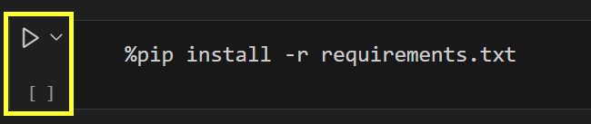

7. Instalacja paczek z pliku `requirements.txt`.

   Uwaga! Jeśli z jakiegoś powodu plik znajduje się poza dostarczonym folderem będzie trzeba podać do niego pełną ścieżkę, zwróć uwagę na podwójne ukośniki.

   ```
   "C:\\Users\\NAZWA_USERA\\Downloads\\requirements.txt"
   ```

```python
%pip install -r requirements.txt
```

[output not shown]

3. Poniższą komendę wykonaj w terminalu. Konfiguruje software niezbędny do pracy z komputerami dwave.

dwave setup

#### Kilka słów o używanych pakietach

- `NumPy` - obliczenia numeryczne, u nas dla efektywnego wykonywania operacji na macierzach
- `Pandas` - obróbka i praca ze zbiorami danych
- `Matplotlib` - wykresy, ogólniej wizualizacje matematyczne
- `Networkx` - działanie na grafach
- `tqdm` - renderowanie paska postępu, dla wygody
- `dwave-ocean-sdk` - komunikacja z dwave i wiele innych przydatnych funkcjonalnalności przydatnych dla naszych modeli, obszerna paczka pakietów

## Dodatkowe wymagania odnośnie GPU

Część szkolenia będzie skupiona na wykorzystaniu możliwości GPU do wspierania obliczeń. Wymagania sprzętowe:

1. Procesor graficzny NVIDIA CUDA o możliwości obliczeniowej (Compute Capability) 3.0 lub wyższej. Niemal wszystkie współczesne karty graficzne spełniają to wymaganie. Listę wspieranych urządzeń znajdziesz [tutaj](https://developer.nvidia.com/cuda-gpus).
2. [CUDA Toolkit](https://developer.nvidia.com/cuda-toolkit): v11.2 / v11.3 / v11.4 / v11.5 / v11.6 / v11.7 / v11.8 / v12.0 / v12.1 / v12.2 / v12.3 / v12.4 / v12.5 / v12.6

By sprawdzić wersję CUDA Toolkit wpisz `nvcc --version` w terminalu.

Do interakcji z GPU będzie potrzebny dodatkowy pakiet Python - `CuPy`. Komenda do instalacji `CuPy` różni się w zależności od posiadanej wersji CUDA Toolkit. W przypadku problemów z instalacją pomoc znajdziesz [tutaj](https://docs.cupy.dev/en/stable/install.html).

```python
# Instalacja CuPy dla v11.2 ~ 11.8

%pip install cupy-cuda11x==13.6
```

```python
# Instalacja CuPy dla v12.x

%pip install cupy-cuda12x==13.6
```

# Dodatkowe środowisko wymagane by wykonać benchmarki

conda deactivate

```python
%pip install ipykernel
%pip install omnisolver-bruteforce
%pip install git+https://github.com/bqth29/simulated-bifurcation-algorithm.git
```

#### Kilka słów o używanych pakietach

- `omnisolver-bruteforce`- wysoko zoptymalizowana implementacja algorytmu wyczerpującego przeszukiwania, która używa podobnego algorytmu co nasza implementacja. [Tutaj](https://github.com/euro-hpc-pl/omnisolver-bruteforce) można znaleźć dodatkowe informacje.
- `Simulated Bifurcation for Python` - implementacja algorytmu symulowanej bifurkacji. [Tutaj](https://github.com/bqth29/simulated-bifurcation-algorithm) można znaleźć dodatkowe informacje.